# for_viz

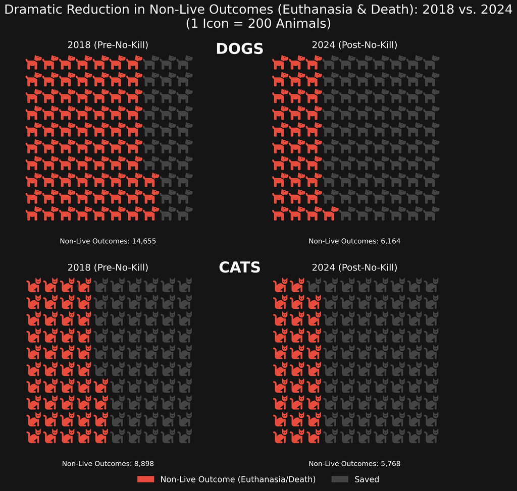

Transfers vs. Negative Outcomes

- Compare the number of pets transferred into Colorado shelters from other states to the number of pets who do not leave shelters alive (euthanasia, died, or missing).
- Assess whether increases in transfers correlate with increases in negative outcomes, or whether the system has capacity to absorb them without increasing deaths.
- Identify whether transfers are supplementing lifesaving by using open capacity—or whether they are straining the system.

[interactive chart not shown]

[interactive chart not shown]

2. Adoption Trends Over Time What to Look For:
- Track adoption numbers year to year, both as raw totals and as a percentage of total intake.
- Identify whether adoption growth is keeping pace with intake growth.
- Examine whether external factors (economic downturns, public crises, or targeted campaigns) produce spikes or drops in adoption rates.

[interactive chart not shown]

3. Return-to-Owner (RTO) Rates What to Look For:
- Compare the percentage of stray pets returned to their owners each year.
- Separate dog and cat RTO rates to identify gaps.
- Track whether interventions like microchipping, lost-and-found platforms, and community education are moving the needle.

[interactive chart not shown]

Based on the RTO Efficiency Bubble Chart, here's what we see:

Dogs are the RTO priority and success story. The dog categories (Adult Dog, Juvenile Dog) have the largest bubbles (highest stray intake volume) and the highest RTO Rates (far right on the X-axis).

Cats have a volume problem but low RTO success. Cat categories (Adult Cat, Juvenile Cat) also make up a large volume (big bubbles), but their RTO Rates are very low (far left on the X-axis).

The "Other" animals have low volume and mixed results. Groups like Rabbit, Reptiles, and Other are small bubbles, meaning they aren't a large part of the stray intake.

Efforts focus on Dogs. The chart clearly shows that RTO programs are highly effective for dogs but need major improvement for cats.

Most stray work is with main domestic pets. The top of the Y-axis (high Stray Intake %) is dominated by both dog and cat bubbles, confirming they are the primary focus of stray intake operations.

4. Intake Categories & Shifts Over Time What to Look For:
- Monitor proportions of stray intake, owner relinquishments, in-state transfers, and out-of-state transfers.
- Identify whether owner surrenders are increasing or decreasing, and whether economic or social factors correlate with those shifts.

[interactive chart not shown]

5. Positive Outcome Pathways What to Look For:
- Break down outcomes into adoption, RTO, in-state transfers, out-of-state transfers, and other positive releases.
- Track whether reliance on one pathway grows or declines relative to others.

[interactive chart not shown]

6. Geographic and Community Variances What to Look For:
- Break down metrics by county or region to see where progress is strongest and where challenges remain.
- Compare save rates, adoption rates, RTO, and intake categories across jurisdictions.

[interactive chart not shown]

[interactive chart not shown]

[interactive chart not shown]